# Stan model_0

# Model_0: Basic model with predicted data

Create fake data

```r
Y = rnorm(10, 1.5, .2)
```

Compile and run the MCMC

```r
fit = stan('../stanModels/model_0.stan', iter=200, chains=4,
           data = list(Y=Y))
```

Interpreting results (with added `generated quantities` block)

```r
print(fit, probs=c(.25, .5, .75))
```

```
Inference for Stan model: model_0.
4 chains, each with iter=200; warmup=100; thin=1;
post-warmup draws per chain=100, total post-warmup draws=400.

               mean se_mean   sd  25%  50%   75% n_eff Rhat
mu             1.47    0.00 0.05 1.44 1.47  1.51   319 1.01
sigma          0.20    0.01 0.05 0.17 0.19  0.22    40 1.11
lSimData[1]    1.48    0.01 0.22 1.34 1.48  1.64   358 1.00
lSimData[2]    1.47    0.01 0.21 1.33 1.47  1.60   411 1.00
lSimData[3]    1.46    0.01 0.22 1.32 1.45  1.59   351 1.00
lSimData[4]    1.46    0.01 0.21 1.35 1.47  1.59   392 1.00
lSimData[5]    1.47    0.01 0.22 1.34 1.47  1.60   362 1.00
lSimData[6]    1.50    0.01 0.20 1.37 1.50  1.64   457 0.99
lSimData[7]    1.48    0.01 0.22 1.34 1.48  1.62   428 1.00
lSimData[8]    1.49    0.01 0.20 1.37 1.49  1.62   364 1.01
lSimData[9]    1.47    0.01 0.21 1.35 1.47  1.60   283 1.01
lSimData[10]   1.47    0.01 0.22 1.35 1.47  1.61   452 0.99
aMax_indicator 0.56    0.03 0.50 0.00 1.00  1.00   250 1.02
aMin_indicator 0.36    0.02 0.48 0.00 0.00  1.00   416 1.01
lp__           9.40    0.08 1.00 8.87 9.74 10.13   157 1.00

Samples were drawn using NUTS(diag_e) at Mon Sep 28 12:46:50 2020.
For each parameter, n_eff is a crude measure of effective sample size,
and Rhat is the potential scale reduction factor on split chains (at
convergence, Rhat=1).
```

Extract and plot posterior

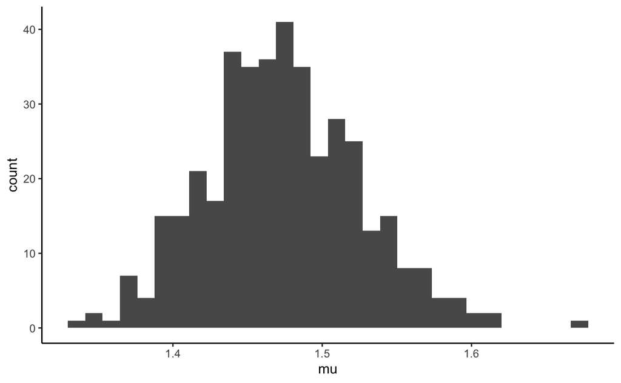

```r
data.frame(mu =extract(fit, 'mu')[[1]]) %>%
  ggplot(aes(x=mu))+
  geom_histogram()
```

Interactive exploration in `shinystan`

```r
# require(shinystan)
```

```r
# aFit = as.shinystan(fit)
# launch_shinystan(aFit)
```

# Model_0.1: Covariate model

New model where height `Y` is a function of weight `X`

```r
N = 100
X = rnorm(N, 60, 10)
beta = .3
sigma = .3
Y = beta * log(X) + rnorm(N, 0, sigma)
fit = stan('../stanModels/model_0.1.stan', iter = 200, chains = 4,
           data = list(Y=Y, X=X, N=N))
```

```r
print(fit, probs=c(.25,.5,.75))
```

```
Inference for Stan model: model_0.
4 chains, each with iter=200; warmup=100; thin=1;
post-warmup draws per chain=100, total post-warmup draws=400.

       mean se_mean   sd   25%   50%   75% n_eff Rhat
beta   0.31    0.00 0.01  0.30  0.31  0.31   402 1.00
sigma  0.30    0.00 0.02  0.28  0.30  0.31   113 1.00
lp__  71.26    0.05 0.77 70.87 71.47 71.84   247 1.01

Samples were drawn using NUTS(diag_e) at Mon Sep 28 12:47:43 2020.
For each parameter, n_eff is a crude measure of effective sample size,
and Rhat is the potential scale reduction factor on split chains (at
convergence, Rhat=1).
```

# Model_0.2: Transformed parameters

Fit new model with `transformed parameters` block

```r
Y = rnorm(10, 1.5, .2)
fit = stan('../stanModels/model_0.2.stan', iter = 200, chains = 4, data= list(Y=Y))
```

```r
print(fit, probs=c(.25,.5,.75))
```

```
Inference for Stan model: model_0.
4 chains, each with iter=200; warmup=100; thin=1;
post-warmup draws per chain=100, total post-warmup draws=400.

         mean se_mean   sd   25%   50%   75% n_eff Rhat
mu       1.50    0.00 0.08  1.44  1.50  1.56   336 1.00
sigmaSq  0.55    0.06 0.54  0.16  0.37  0.74    71 1.06
sigma    0.66    0.04 0.33  0.40  0.61  0.86    62 1.08
lp__    -1.54    0.06 0.78 -1.93 -1.34 -0.92   158 1.02

Samples were drawn using NUTS(diag_e) at Mon Sep 28 12:47:56 2020.
For each parameter, n_eff is a crude measure of effective sample size,
and Rhat is the potential scale reduction factor on split chains (at
convergence, Rhat=1).
```

# Model_0.3: Avoiding memory overload

Creating posterior predictive check variable within `{}` to avoid memory overhead.

```r
Y = rnorm(10, 1.5, .2)
fit = stan('../stanModels/model_0.3.stan', iter = 200, chains = 4, data= list(Y=Y))
```

Note lack of `lSimData` variable in the output

```r
print(fit, probs=c(.25,.5,.75))
```

```
Inference for Stan model: model_0.
4 chains, each with iter=200; warmup=100; thin=1;
post-warmup draws per chain=100, total post-warmup draws=400.

                mean se_mean   sd  25%   50%   75% n_eff Rhat
mu              1.50    0.00 0.05 1.47  1.50  1.53   428 0.99
sigma           0.20    0.01 0.05 0.16  0.19  0.23    70 1.02
aMax_indicator  0.72    0.03 0.45 0.00  1.00  1.00   288 1.01
aMin_indicator  0.53    0.03 0.50 0.00  1.00  1.00   323 1.00
lp__           10.29    0.11 1.01 9.85 10.62 11.02    80 1.02

Samples were drawn using NUTS(diag_e) at Mon Sep 28 13:49:13 2020.
For each parameter, n_eff is a crude measure of effective sample size,
and Rhat is the potential scale reduction factor on split chains (at
convergence, Rhat=1).
```

# Model_0.4: Custom distributions

Creating custom probability distributions.

```r
N = 4
X = c(-1.5, 2.3, 0.1, -0.4)
fit = stan('../stanModels/model_0.4.stan', iter = 200, chains = 4, data= list(N=N, X=X))
```

```r
print(fit, probs=c(.25,.5,.75))
```

```
Inference for Stan model: model_0.
4 chains, each with iter=200; warmup=100; thin=1;
post-warmup draws per chain=100, total post-warmup draws=400.

      mean se_mean   sd   25%  50%   75% n_eff Rhat
mu   -0.08    0.06 0.55 -0.49 -0.1  0.32    98 1.06
lp__ -8.69    0.06 0.71 -8.91 -8.4 -8.23   160 1.02

Samples were drawn using NUTS(diag_e) at Mon Sep 28 14:10:55 2020.
For each parameter, n_eff is a crude measure of effective sample size,
and Rhat is the potential scale reduction factor on split chains (at
convergence, Rhat=1).
```

# Model_0.5 and Model_0.6: WAIC and LOO-CV

Using WAIC and LOO-CV

Generate data from a t-distribution and compare two models that describe a true and false data generating processes.

```r
N = 10000
X = rt(N, 5)
```

```r
require(loo)
```

Compare models using `WAIC`

```r
fit1 = stan('../stanModels/model_0.5.stan', iter=200, chains=4, data=list(N=N, X=X))
logLikelihood1 = extract_log_lik(fit1, 'logLikelihood')
WAIC1 = waic(logLikelihood1)
```

```r
WAIC1
```

```
Computed from 400 by 10000 log-likelihood matrix
```

|  | Estimate | SE |
| --- | --- | --- |
| elpd_waic | -16981.7 | 139.8 |
| p_waic | 4.9 | 0.8 |
| waic | 33963.4 | 279.5 |

```
2 (0.0%) p_waic estimates greater than 0.4. We recommend trying loo instead.
```

```r
fit2 = stan('../stanModels/model_0.6.stan', iter=200, chains=4, data=list(N=N, X=X))
logLikelihood2 = extract_log_lik(fit2, 'logLikelihood')
WAIC2 = waic(logLikelihood2)
```

```r
WAIC2
```

```
Computed from 400 by 10000 log-likelihood matrix
```

|  | Estimate | SE |
| --- | --- | --- |
| elpd_waic | -16379.2 | 94.8 |
| p_waic | 3.2 | 0.1 |
| waic | 32758.3 | 189.5 |

Difference in `elpd` is much greater than the standard error; i.e. there is a significant difference in performance between the two models.

```r
loo_compare(WAIC1, WAIC2)
```

[output not shown]

Compare models using `LOO-CV`

```r
LOO1 = loo(logLikelihood1)
```

```
Relative effective sample sizes ('r_eff' argument) not specified.
For models fit with MCMC, the reported PSIS effective sample sizes and
MCSE estimates will be over-optimistic.
```

```r
LOO1
```

```
Computed from 400 by 10000 log-likelihood matrix
```

|  | Estimate | SE |
| --- | --- | --- |
| elpd_loo | -16981.7 | 139.8 |
| p_loo | 4.9 | 0.8 |
| looic | 33963.5 | 279.5 |

```
------
Monte Carlo SE of elpd_loo is 0.1.

All Pareto k estimates are good (k < 0.5).
See help('pareto-k-diagnostic') for details.
```

```r
LOO2 = loo(logLikelihood2)
```

```
Relative effective sample sizes ('r_eff' argument) not specified.
For models fit with MCMC, the reported PSIS effective sample sizes and
MCSE estimates will be over-optimistic.
```

```r
LOO2
```

```
Computed from 400 by 10000 log-likelihood matrix
```

|  | Estimate | SE |
| --- | --- | --- |
| elpd_loo | -16379.2 | 94.8 |
| p_loo | 3.2 | 0.1 |
| looic | 32758.4 | 189.5 |

```
------
Monte Carlo SE of elpd_loo is 0.1.

All Pareto k estimates are good (k < 0.5).
See help('pareto-k-diagnostic') for details.
```

```r
loo_compare(LOO1, LOO2)
```

[output not shown]

# Model_0.7 and Model_0.8: Explicit CV

Explicit cross validation

```r
require(caret)
```

```r
kFold = function(aModel, testIndices, X){
  numFolds = length(testIndices)

  lPointLogLikelihoodTotal = vector()

  for(i in 1:numFolds){
    XTest = X[testIndices[[i]]]
    XTrain = X[-testIndices[[i]]]
    fit = sampling(aModel, iter=200, chains=4, data=list(NTest=2000, NTrain=8000, XTrain=XTrain, XTest=XTest))
    logLikelihood1 = extract_log_lik(fit, 'logLikelihood')
    lPointLogLikelihood1 = colMeans(logLikelihood1)
    lPointLogLikelihoodTotal = c(lPointLogLikelihoodTotal, lPointLogLikelihood1)
  }

  return(lPointLogLikelihoodTotal)
}
```

```r
Model1 = stan_model('../stanModels//model_0.7.stan')
Model2 = stan_model('../stanModels//model_0.8.stan')
```

```r
lELPD1 = kFold(Model1, testIndices, X)
lELPD2 = kFold(Model2, testIndices, X)
```

```r
sum(lELPD1)
```

```
[1] -16983.47
```

```r
sum(lELPD2)
```

```
[1] -16379.04
```

# Model_0.9: Transformed parameters

Transformed parameters and Jacobians

Example model where the defined parameter `alpha` does not have prior defined in the `model` but instead we specify a parameter for the transformed parameter `theta`. This will give a warning and an incorrect estimate for `theta` because nonilnear transformations on parameters that are then used for sampling require the definition of a Jacobian (i.e. the description of how the nonlinear transform changes the probability density of the transformed parameter compared to the original)

```r
N=4
Y=c(0,0,1,0)
fit = stan('../stanModels/model_0.9.stan', iter=200, chains=4, data=list(N=N, Y=Y))
```

```
DIAGNOSTIC(S) FROM PARSER:
Info:
Left-hand side of sampling statement (~) may contain a non-linear transform of a parameter or local variable.
If it does, you need to include a target += statement with the log absolute determinant of the Jacobian of the transform.
Left-hand-side of sampling statement:
    theta ~ uniform(...)
```

[output not shown]

[output not shown]

```r
print(fit, probs=c(.25,.5,.75))
```

```
Inference for Stan model: model_0.
4 chains, each with iter=200; warmup=100; thin=1;
post-warmup draws per chain=100, total post-warmup draws=400.

       mean se_mean   sd   25%   50%   75% n_eff Rhat
alpha -1.39    0.10 1.22 -2.24 -1.29 -0.57   138 1.02
theta  0.25    0.02 0.19  0.10  0.22  0.36   138 1.02
lp__  -2.73    0.04 0.60 -2.96 -2.49 -2.31   285 1.01

Samples were drawn using NUTS(diag_e) at Mon Sep 28 16:21:58 2020.
For each parameter, n_eff is a crude measure of effective sample size,
and Rhat is the potential scale reduction factor on split chains (at
convergence, Rhat=1).
```

# Model_0.10: Jacobians

Corrected model where the log probability is correctly updated using the Jacobian

```r
fit = stan('../stanModels/model_0.10.stan', iter=200, chains=4, data=list(N=N, Y=Y))
```

```r
print(fit, probs=c(.25,.5,.75))
```

[output not shown]

# Model_0.11: Discrete variables

Estimating coin identity and head probability of two biased coins in 20 experiments with 10 coin flips each.

Generate fake data

```r
nStudy = 20
N = 10
Z = matrix(nrow=N, ncol=nStudy)
theta = c(.1, .9)
state = vector(length = nStudy)
for (i in 1:nStudy){
  if (runif(1)<.5){
    Z[,i] = rbinom(N, 1, theta[1])
    state[i] = 1
  } else{
    Z[,i] = rbinom(N, 1, theta[2])
    state[i] = 0
  }
}

Z = colsums(Z)
```

```
Error in colsums(Z) : could not find function "colsums"
```

```r
state
```

```
 [1] 1 0 0 0 1 1 1 1 0 1 1 0 0 1 0 1 0 1 1 0
```

```r
fit = stan('../stanModels/model_0.11.stan', iter=200, chains=4, data=list(X=X, N=N, nStudy=nStudy))
```

```r
print(fit, probs = c(.25,.5,.75), c('theta', 'pstate'))
```

```
Inference for Stan model: model_0.
4 chains, each with iter=200; warmup=100; thin=1;
post-warmup draws per chain=100, total post-warmup draws=400.

           mean se_mean   sd  25%  50%  75% n_eff Rhat
theta[1]   0.09       0 0.03 0.07 0.09 0.11    52 1.08
theta[2]   0.87       0 0.04 0.84 0.87 0.89   377 0.99
pstate[1]  1.00       0 0.00 1.00 1.00 1.00   349 1.00
pstate[2]  0.00       0 0.00 0.00 0.00 0.00    82 1.07
pstate[3]  0.00       0 0.00 0.00 0.00 0.00    58 1.10
pstate[4]  0.00       0 0.00 0.00 0.00 0.00    67 1.09
pstate[5]  1.00       0 0.00 1.00 1.00 1.00   387 0.99
pstate[6]  1.00       0 0.00 1.00 1.00 1.00   386 0.99
pstate[7]  1.00       0 0.00 1.00 1.00 1.00   349 1.00
pstate[8]  1.00       0 0.00 1.00 1.00 1.00   386 0.99
pstate[9]  0.00       0 0.00 0.00 0.00 0.00    58 1.10
pstate[10] 0.99       0 0.01 1.00 1.00 1.00   310 1.01
pstate[11] 1.00       0 0.00 1.00 1.00 1.00   349 1.00
pstate[12] 0.00       0 0.00 0.00 0.00 0.00    60 1.09
pstate[13] 0.00       0 0.00 0.00 0.00 0.00    67 1.09
pstate[14] 1.00       0 0.00 1.00 1.00 1.00   386 0.99
pstate[15] 0.00       0 0.00 0.00 0.00 0.00    60 1.09
pstate[16] 1.00       0 0.00 1.00 1.00 1.00   386 0.99
pstate[17] 0.00       0 0.00 0.00 0.00 0.00    60 1.09
pstate[18] 1.00       0 0.00 1.00 1.00 1.00   349 1.00
pstate[19] 1.00       0 0.00 1.00 1.00 1.00   386 0.99
pstate[20] 0.00       0 0.00 0.00 0.00 0.00    82 1.07

Samples were drawn using NUTS(diag_e) at Tue Sep 29 11:56:22 2020.
For each parameter, n_eff is a crude measure of effective sample size,
and Rhat is the potential scale reduction factor on split chains (at
convergence, Rhat=1).
```